# Manual Least Squares App for Polynomial Regression

2022-08-30

## Motivation

Math heavy topics are often relevant in all sorts of scientific fields, but the theoretical nature of them often makes them hard to approach. I think what would make it much easier for researchers and students if math education would consider more hands-on or even gamified teaching methods. I would even argue that this could lead to deeper understanding and better intuition for math heavy methodologies. As an example for such a teaching method I build a shiny app where the user can try and fit a polynomial regression onto simulated data. I hope this achieves a hands-on and fun experience learning about least squares and polynomial regression.

## How the data is simulated

x values are uniformly randomized. Then for each polynomial term (up to the 3rd degree) we randomize if it is included and if it is, a coefficient for it. After all terms we add a bit of random normal noise.

```r
x    <- runif(40,min = -10,max = 10)
b0 <- ifelse(runif(1,0,1) > 0.5,0,round(runif(1,-10,10)))
b1 <- ifelse(runif(1,0,1) > 0.5,0,round(runif(1,-10,10)))
b2 <- ifelse(runif(1,0,1) > 0.5,0,round(runif(1,-10,10)))
b3 <- ifelse(runif(1,0,1) > 0.5,0,round(runif(1,-10,10)))
y_noNoise <- b3*x^3 + b2*x^2 + b1*x + b0
sd_noise <- ifelse(max(y_noNoise)>abs(min(y_noNoise)),
                   max(y_noNoise)/5 + .1,
                   abs(min(y_noNoise))/5+.1)
y <- y_noNoise + rnorm(length(y_noNoise), sd = sd_noise)
df <- data.frame(x, y)
```

## Plotting

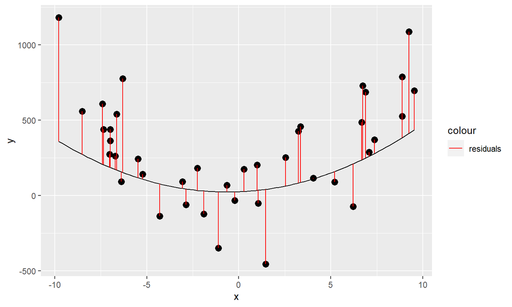

## Thanks

for visiting and I hope you enjoy the app :)